# Semibalanus mortality analysis

Amelia Hesketh

06/10/2021

## Objectives

Following the heat dome of 2021, my goal was to document resultant impacts on the mortality of the bed-forming thatched barnacle *Semibalanus cariosus*, and the determine the dominant factors underlying any mortality patterns observed.

## Data involved

The response, barnacle mortality, is a percentage value obtained by counting the number of live and number of dead barnacles present in 12.7 x 12.7 cm quadrats along haphazardly placed transects at each site (10 quadrats/transect, 1-3 transects per site). Algal cover and the number of anemones (*Anthopleura elegantissima*) in each quadrat were documented in most cases to serve as covariates.

Temperature data was obtained from Climate Canada. While numerous temperature metrics may be suitable, we will attempt to use the a) mean daily maximum temperature during the heat dome period in British Columbia (June 25-29), and b) mean daily maximum temperature during the start of summer to the time of each mortality survey.

In addition, we will consider the longitude of each site as a covariate (approximating distance from the more temperate outer coast). Given that topography and aspect varied within each site, it seems unlikely that using the dominant shore aspect will serve any major purpose.

## Modeling approach

We will attempt to model mortality using a generalized linear modeling approach with a beta family (given that proportion data are being used). We may need to transform the data in order to pull zero mortality data above zero, since GLMMTMB can only handle data on the interval (0,1), not [0,1].

## Assembling temperature data

```r
library(tidyverse)

# first, assemble all relevant air temperature data

temp.files <- list.files("./raw_data/air_temp/")

# join together all the files

for (file in 1: length(temp.files)){
  file.name = paste("./raw_data/air_temp/", temp.files[file], sep = "")
  file.name.len = nchar(file.name)
  site.name = substr(file.name, (file.name.len-5), (file.name.len-4))
  temp.df <- read_csv(file.name, col_select = c(5:8, 10, 14)) %>%
    filter(`Date/Time` >= "2021-06-01" & `Date/Time` < "2021-09-01") %>%
    mutate(site_code = site.name)
  if (file == 1){
    temp.df.all <- temp.df
  }
  if (file > 1){
    temp.df.all <- rbind(temp.df.all, temp.df)
  }
}

# now to rename the columns for ease of coding later
temp.df.rename <- temp.df.all %>% rename("date" = 1, "year" = 2,"month" = 3, "day" = 4, "max_temp_C" = 5, "mean_temp_C" = 6)

# need to next associate each site with a sampling date, and filter out any temp data that was recorded after

survey.info <- read_csv("./raw_data/SBC_siteinformation.csv") %>%
  select(site_code, latitude_degrees, longitude_degrees, mortality, mortality_survey) %>%
  na.omit()

survey.dates <- survey.info %>% select(site_code, mortality_survey)

# now join to temperature data, leaving out sites we don't yet have mortality data for

required.temp.data <- temp.df.rename %>% right_join(survey.dates) %>%
  filter(date < mortality_survey) %>% select(-mortality_survey)

# now summarize mean daily temperature values that we care about across whole period

temp.summary <- required.temp.data %>%
  group_by(site_code) %>% summarize(mean_daily_temp = mean(mean_temp_C, na.rm=T), mean_daily_max_temp = mean(max_temp_C, na.rm=T))

# now just for the heat wave period

temp.hw.only <- temp.df.rename %>% filter(date <= "2021-06-29" & date >= "2021-06-25")

temp.hw.summary <- temp.hw.only %>%
  group_by(site_code) %>% summarize(mean_daily_temp_hw = mean(mean_temp_C, na.rm=T), mean_daily_max_temp_hw = mean(max_temp_C, na.rm=T))

# join to site information data frame

explanatory.variables <- survey.info %>% left_join(temp.hw.summary) %>%
  full_join(temp.summary) %>% select(-mortality, -mortality_survey, -latitude_degrees)
```

# Generating dataframe for modeling

```r
# now to get response data read in

mortality <- read_csv("./raw_data/mortality/SBC_MORT_surveys.csv") %>%
  select(-cover_live, -cover_dead, -algal_cover_per25sq)

mort.model.df <- mortality %>% full_join(explanatory.variables) %>%
  mutate(prop_dead = number_dead/(number_dead+number_live))
```

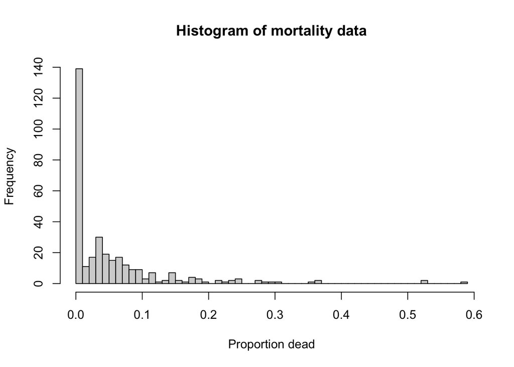

```r
# examining the mortality data

hist(mort.model.df$prop_dead, breaks = 50, xlab = "Proportion dead", main = "Histogram of mortality data")
```

Based on the distribution of these data, a beta model may not be the way to go. The data have an extreme case of zero-inflation, but I don’t believe that different processes are causing mortality vs. no mortality, so a hurdle ZOIB model seems inappropriate. Starting off with a Tweedie distribution, while imperfect, may be the best option.

# Model building

Our initial explantory variables will include:

- mean max daily temperature (whole period)
- mean max daily temperature (heat dome only)
- longitude
- algal cover
- number of anemones

Random effects will include:

- site
- transect nested within site

```r
library(glmmTMB)
library(GGally)
```

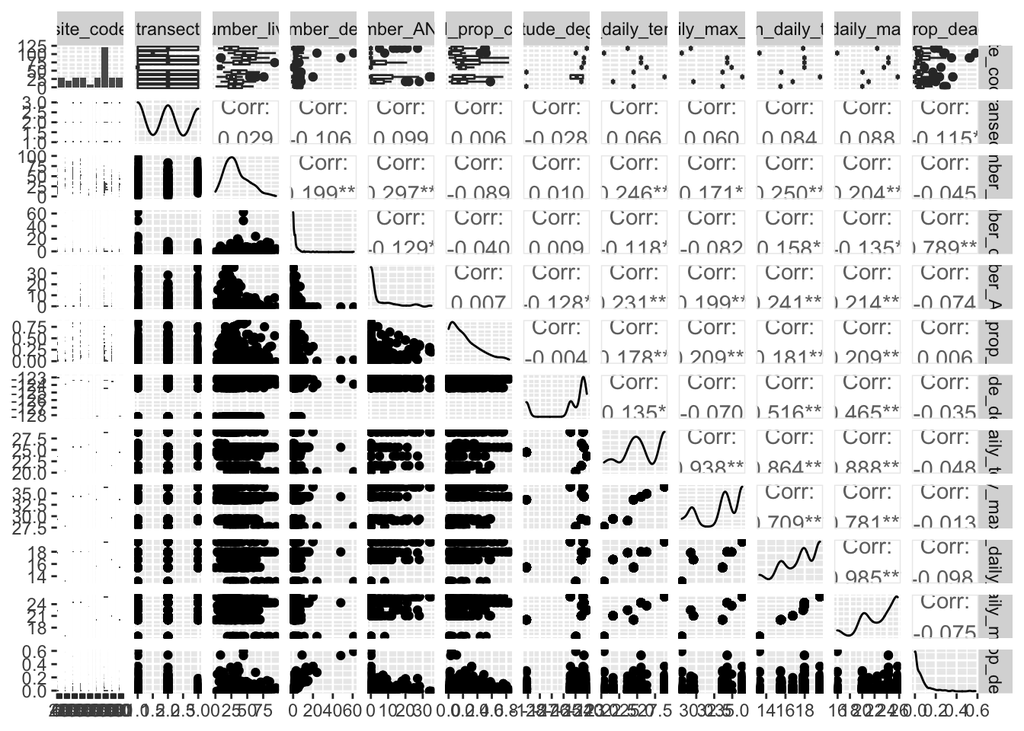

```r
mort.mod.1 <- glmmTMB(prop_dead ~ mean_daily_max_temp + mean_daily_max_temp_hw + longitude_degrees + algal_prop_cover + number_ANEL + (1 | site_code), data = mort.model.df, family = tweedie())

ggpairs(mort.model.df)
```